# **Raport z odtwarzania artykułu: An interpretable mortality prediction model for COVID-19 patients**

*Chrupki&Chmurki: Kinga Ułasik, Dawid Przybyliński, Hubert Ruczyński*

# **Wygenerowane dane**

Pierwszy blok kodu generuje następujące tabele i wykresy z artykułu oraz dodatku:

- Tabela z danymi do Supplementary Figure 1
- Supplementary Figure 1
- Niezformatowane i rozszerzone dane przedstawione w Table 3 (Jednak różniące się w niewielkim stopniu na pierwszym, bądź drugim miejscu po przecinku). Dane te użyte są także do stworzenia Supplementary Figure 2.
- Confusion matrix dla Supplementary Table 1
- Supplementary Table 1
- Confusion matrix dla Supplementary Table 2
- Supplementary Table 2
- Supplementary Figure 5
- Niezformatowane Table 4
- Niezformatowane drzewo z Fig 2. Wizulaizacja przedstawiona w raporcie wygląda na zrobioną bezpośrednio w programie graficznym, co znacznie ją 'uładnia'.
- Supplementary Table 3 w postaci tekstu
- Supplementary Figure 4 (A)

```
findfont: Font family ['sans-serif'] not found. Falling back to DejaVu Sans.
findfont: Font family ['sans-serif'] not found. Falling back to DejaVu Sans.
```

```
Top 10 features:
                                          col       xgb
6                       Lactate dehydrogenase  0.318778
19                              (%)lymphocyte  0.075238
39        High sensitivity C-reactive protein  0.040039
38                               serum sodium  0.035594
21                             eosinophils(%)  0.028392
35                             Serum chloride  0.027726
33                               monocytes(%)  0.026994
41               International standard ratio  0.026934
4   mean corpuscular hemoglobin concentration  0.024443
31                             neutrophils(%)  0.023397
```

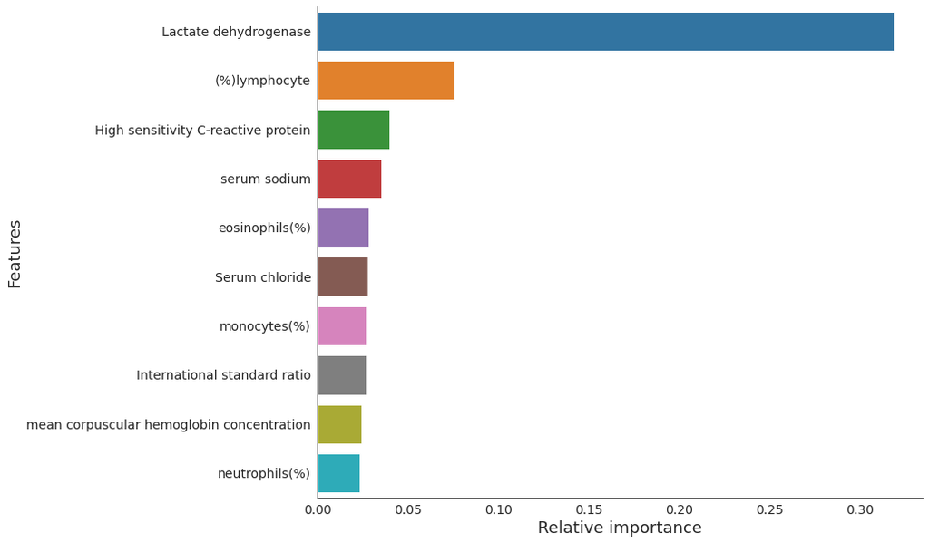

```
['Lactate dehydrogenase']
5-Fold CV:
Train AUC-score is 0.9430 ; Validation AUC-score is 0.9227
Train AUC-score-std is 0.0082 ; Validation AUC-score-std is 0.0272
['Lactate dehydrogenase' '(%)lymphocyte']
5-Fold CV:
Train AUC-score is 0.9672 ; Validation AUC-score is 0.9422
Train AUC-score-std is 0.0048 ; Validation AUC-score-std is 0.0251
['Lactate dehydrogenase' '(%)lymphocyte'
 'High sensitivity C-reactive protein']
5-Fold CV:
Train AUC-score is 0.9784 ; Validation AUC-score is 0.9495
Train AUC-score-std is 0.0040 ; Validation AUC-score-std is 0.0234
['Lactate dehydrogenase' '(%)lymphocyte'
 'High sensitivity C-reactive protein' 'serum sodium']
5-Fold CV:
Train AUC-score is 0.9783 ; Validation AUC-score is 0.9498
Train AUC-score-std is 0.0039 ; Validation AUC-score-std is 0.0232
['Lactate dehydrogenase' '(%)lymphocyte'
 'High sensitivity C-reactive protein' 'serum sodium' 'eosinophils(%)']
5-Fold CV:
Train AUC-score is 0.9799 ; Validation AUC-score is 0.9527
Train AUC-score-std is 0.0036 ; Validation AUC-score-std is 0.0226
['Lactate dehydrogenase' '(%)lymphocyte'
 'High sensitivity C-reactive protein' 'serum sodium' 'eosinophils(%)'
 'Serum chloride']
5-Fold CV:
Train AUC-score is 0.9804 ; Validation AUC-score is 0.9549
Train AUC-score-std is 0.0035 ; Validation AUC-score-std is 0.0238
['Lactate dehydrogenase' '(%)lymphocyte'
 'High sensitivity C-reactive protein' 'serum sodium' 'eosinophils(%)'
 'Serum chloride' 'monocytes(%)']
5-Fold CV:
Train AUC-score is 0.9803 ; Validation AUC-score is 0.9541
Train AUC-score-std is 0.0036 ; Validation AUC-score-std is 0.0235
Selected features: ['Lactate dehydrogenase' '(%)lymphocyte'
 'High sensitivity C-reactive protein' 'serum sodium' 'eosinophils(%)'
 'Serum chloride']
single_tree:
```

```
findfont: Font family ['sans-serif'] not found. Falling back to DejaVu Sans.
findfont: Font family ['sans-serif'] not found. Falling back to DejaVu Sans.
```

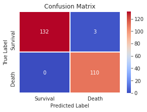

```
              precision    recall  f1-score   support

         0.0       1.00      0.98      0.99       135
         1.0       0.97      1.00      0.99       110

    accuracy                           0.99       245
   macro avg       0.99      0.99      0.99       245
weighted avg       0.99      0.99      0.99       245
```

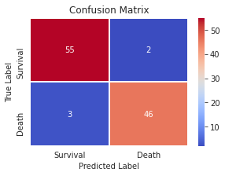

```
              precision    recall  f1-score   support

         0.0       0.95      0.96      0.96        57
         1.0       0.96      0.94      0.95        49

    accuracy                           0.95       106
   macro avg       0.95      0.95      0.95       106
weighted avg       0.95      0.95      0.95       106

True test label: [0 0 1 0 0 0 0 0 0 0 0 0 0 0 0 0 0 0 0 0 0 0 0 0 0 0 0 1 1 0 0 0 0 0 0 0 0
 0 0 0 0 0 0 0 0 0 0 0 0 0 0 0 0 0 0 1 0 0 0 0 1 0 0 0 0 0 0 0 0 0 0 0 0 0
 0 1 0 0 1 1 0 0 0 0 0 1 0 0 0 0 1 0 0 0 0 1 0 0 0 0 0 0 0 0 0 1 0 0 1 0]
Predict test label: [0 0 1 0 0 0 0 0 0 0 0 0 0 0 0 0 0 0 0 0 0 0 1 0 0 0 0 1 1 0 0 0 0 0 0 0 0
 0 0 1 0 0 0 0 0 0 0 0 0 0 0 0 0 0 0 1 0 0 0 0 1 0 0 0 0 0 0 0 0 0 0 0 0 0
 0 1 0 0 1 1 0 0 0 0 0 1 0 0 0 0 1 0 0 0 0 1 0 0 0 0 0 0 0 0 0 1 0 0 1 1]
```

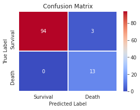

```
              precision    recall  f1-score   support

           0       1.00      0.97      0.98        97
           1       0.81      1.00      0.90        13

    accuracy                           0.97       110
   macro avg       0.91      0.98      0.94       110
weighted avg       0.98      0.97      0.97       110
```

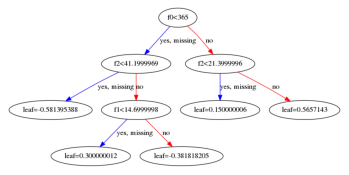

```
Compare with other methods
Model:Multi-tree XGBoost with all features
AUC of Train:1.000000 with std:0.0000
AUC of Validation:0.997230 with std:0.0039
AUC socre: 0.9944974321349963
Model:Decision tree with all features
AUC of Train:0.998855 with std:0.0018
AUC of Validation:0.938872 with std:0.0284
AUC socre: 0.931584739545121
Model:Random Forest with all features
AUC of Train:1.000000 with std:0.0000
AUC of Validation:0.996875 with std:0.0037
AUC socre: 0.9937637564196624
Model:Logistic regression with all features with regularization parameter = 1 (by default)
AUC of Train:0.999959 with std:0.0001
AUC of Validation:0.968366 with std:0.0235
AUC socre: 0.958180484225972
Model:Logistic regression with all features with regularization parameter = 10
AUC of Train:0.999902 with std:0.0002
AUC of Validation:0.970177 with std:0.0234
AUC socre: 0.9677182685253117
ModelSingle-tree XGBoost with three features
AUC of Train:0.995988 with std:0.0027
AUC of Validation:0.975763 with std:0.0181
AUC socre: 0.9491929567131329
ModelDecision tree with three features
AUC of Train:0.994919 with std:0.0034
AUC of Validation:0.955417 with std:0.0278
AUC socre: 0.950843727072634
ModelRandom Forest with a single tree constraint with three features
```

```
findfont: Font family ['sans-serif'] not found. Falling back to DejaVu Sans.
```

```
AUC of Train:0.982424 with std:0.0085
AUC of Validation:0.964320 with std:0.0248
AUC socre: 0.8785766691122524
```

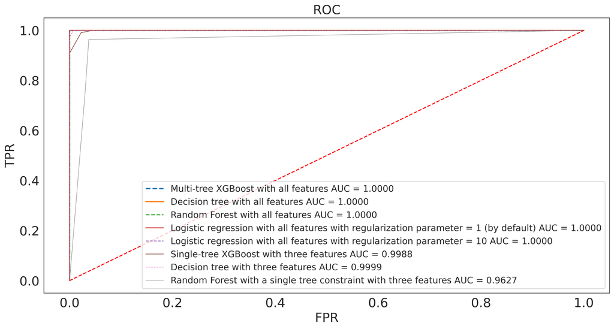

```python
selected_cols = features_selection()
single_tree()
print('Compare with other methods')
Compare_with_other_method(selected_cols)
```

# **Wygenerowane dane**

Drugi blok "EDA" generuje wykresy B, C, D, E z Figure 3

# **EDA**

```
findfont: Font family ['Tahoma'] not found. Falling back to DejaVu Sans.
```

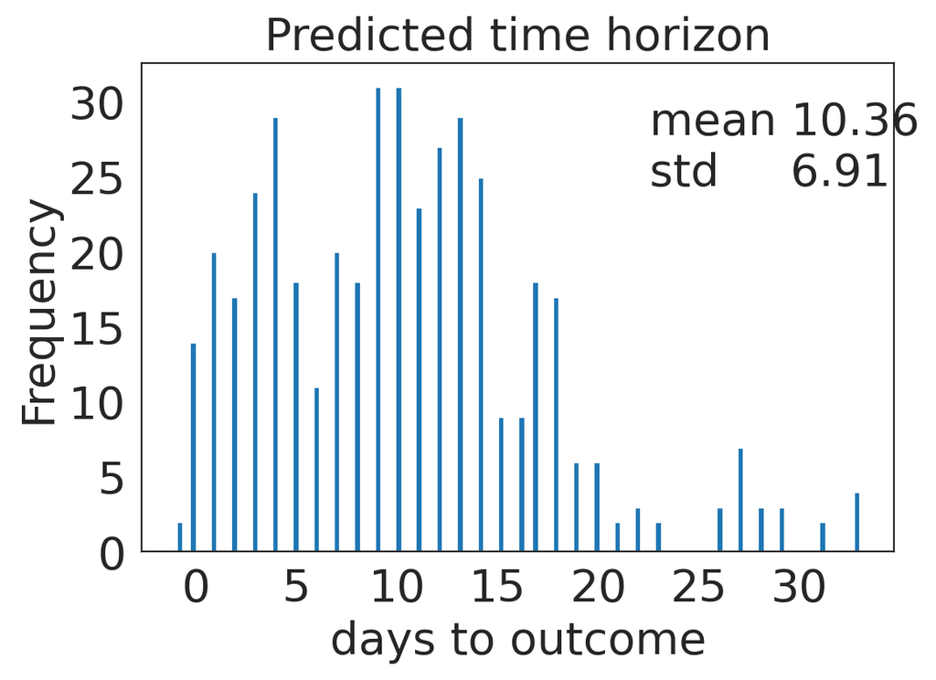

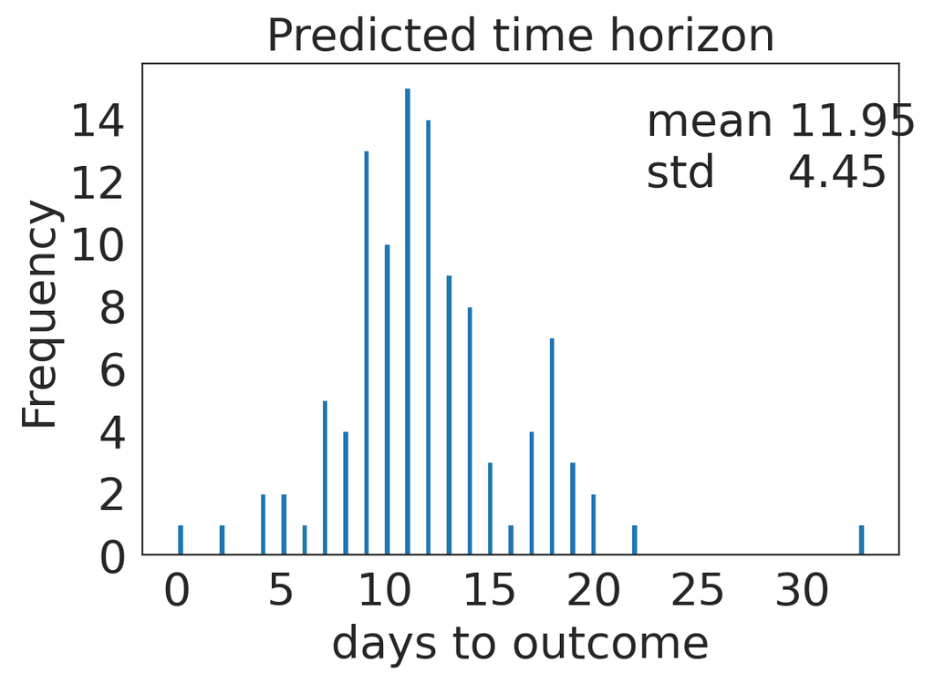

```
======================== first 1 Discount index ========================>

======================== overall index ========================>
              precision    recall  f1-score   support

           0       0.96      0.85      0.90       347
           1       0.85      0.96      0.90       311

    accuracy                           0.90       658
   macro avg       0.90      0.90      0.90       658
weighted avg       0.91      0.90      0.90       658

accuracy：	 0.8997
F1-score：	 0.8997
confusion matrix：
[[294  53]
 [ 13 298]]

======================== first 1 Discount index ========================>

======================== overall index ========================>
              precision    recall  f1-score   support

           0       0.99      0.91      0.95       182
           1       0.80      0.97      0.88        69

    accuracy                           0.92       251
   macro avg       0.89      0.94      0.91       251
weighted avg       0.94      0.92      0.93       251

accuracy：	 0.9243
F1-score：	 0.9107
confusion matrix：
[[165  17]
 [  2  67]]

======================== first 1 Discount index ========================>

======================== overall index ========================>
              precision    recall  f1-score   support

           0       0.97      0.87      0.92       529
           1       0.84      0.96      0.90       380

    accuracy                           0.91       909
   macro avg       0.90      0.91      0.91       909
weighted avg       0.91      0.91      0.91       909

accuracy：	 0.9065
F1-score：	 0.9055
confusion matrix：
[[459  70]
 [ 15 365]]
Number of patients：485
Minimum length of hospital stay：0 days 02:01:58
Maximum length of hospital stay：35 days 04:05:54
Median length of hospital stay：11 days 04:15:36
```

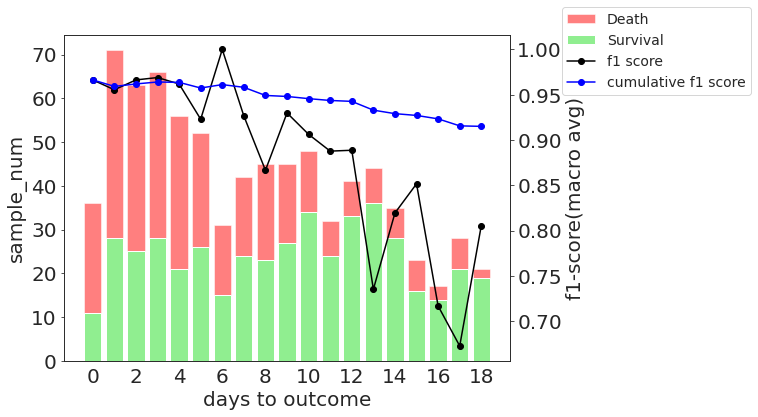

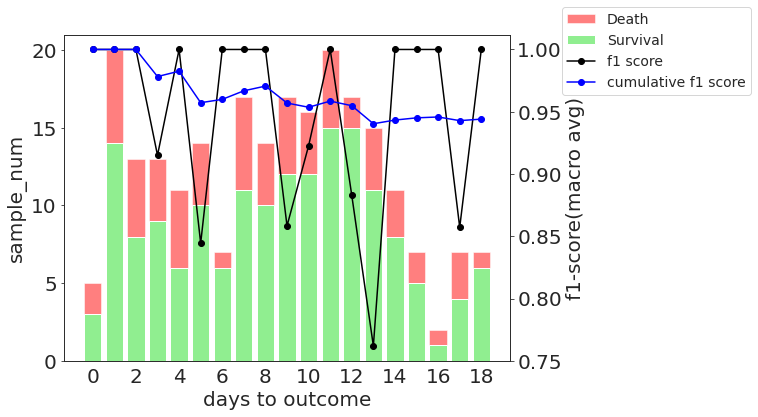

```python
predicted_time_horizon()
decision_tree_top3_feats_predict_result()
hospitalization_time()
plot_f1_time_single_tree_test_train()
```

# **Analiza Artykułu**

Zalety:

- Doskonale wyjaśniający temat wstęp, który ujawnia motywacje stojącą za wykonaną pracą. Samo badanie jest bardzo szybką reakcją na dziejący się na świecie problem i dąży do uzyskania dobra ogólnego co także jest warte docenienia.
- Jasno wytłumaczone kryteria diagnostyczne oraz kryteria klasyfikacji stanu zdrowia w przejrzysty sposób ukazują nam profile badanych pacjentów.
- Informacja o tym, że dane pochodzą z placówki która przyjmowała ciężkie przypadki z innych miejsc. Wspomnienie o tym jest niezwykle istotne, gdyż dane, zwłaszcza o zgonach i ozdrowieniach, drastycznei różnią się od tych przedstawionych w artykule [1].
- Podanie parametrów przy ktorych tworzony był model XGBoost jest także czymś godnym odnotowania, gdyż dzięki temu zapewnioną mamy reprodukowalność modelu.
- Supplementary File zawiera bardzo dużo ciekawych danych i potwierdzeń, że obrana metoda (XGBoost) faktycznie wykazywałą najwyższą skuteczność. Potwierdzenie w takiej postaci niewątpliwie utwierdza odbiorcę w rzetelności artykułu i badań.

Wady:

- Na pierwszy rzut oka dane procentowe w `Table 2` nie są tak szybko rozpoznawane. Przy liczbach powinien być dopisany znak procenta, albo powinny być podane w osobnej kolumnie. Jest to szczególnie istotne gdyż to one raczej interesują czytelnika i niosą za sobą więcej informacji.
- Plik z dodatkowymi danymi (nazywajmy go `Supplementary File`) z dodatkowymi tabelami i wizualizacjami jest bardzo ukryty i znalezienie go nie należy do najłatwiejszych. Ponadto niektóre wizualizacje powinny były znaleźć się w raporcie. W szczególności `Supplementary Table 3` i `Supplementary Figure 1`.
- Supplementary Figure 3 jest nie do końca nieczytelny przez dodanie markerów w kształcie niewyraźnego X w połączeniu z rozmywającym się jasno-różowym kolorem.
- Supplementary File ma zachwianą kolejność tabel i wizualizacji, gdyż nie występują one w tej samej kolejności co w tekście. Oczywiście chodzi nam tutaj o pierwsze wspominanie o poszczególnych wizualizacjach. Niestety niejednokrotnie skakanie po dodatku wydaje się uciążliwe, a jego struktura nie do końca przemyślana.
- Dość niski wskaźnik accuracy dla przewidywania śmiertelności jest frapujący dla wytrenowanego modelu. Można to zobrazować w taki sposób, że około 20% miejsc w szpitalach jest zajętych niepotrzebnie, co znając późniejszy rozwój pandemii wydaje się bardzo niezadowalającym rezultatem, choć w tamtym okresie mogło wydawać się dobre.

# **Odwołania do inych Artykułów:**

**[1] Epidemiological and clinical characteristics of 99 cases of 2019 novel coronavirus pneumonia in Wuhan, China: a descriptive study**

*Temat:*

Charakterystyka jednych z pierwszych przypadków chorowania na koronawirusa. Przytaczanie charakterystyk osób zarażonych Covidem w bardzo szerokim spektrum, obejmującym wiek, płeć, zawód, objawy, choroby przwlekłe, a także poziom ekspozycji na pierwsze ognisko wirusa (market owoców morza w Huanan, Wuhan).

*Powód przytoczenia:*

Artykuł przytoczony został dwukrotnie. Za pierwszym razem miał na celu wskazać, źródło które potwierdza wiarygodność informacji na temat procentowej ilości ciężkich przypadków koronawirusa. Za drugim razem z kolei wyjaśnia o jakich wskaźnikach wysokiego ryzyka mowa.

*Ciekawe informacje:*

Przede wszystkim interesujący jest fakt, że wirus tak syzbko rozprzestrzenił się poprzez osoby odwiedzające i pracujące w tym Huanańskim markecie. Z danych wynika, że aż 49% pacjentów przebywało w tym miejscu.

Ponadto ciekawy jest także fakt, że połowa przypadków (51%) miała także współtowarzyszące choroby przewlekłe, co pokazuje że Covid-19 działa silniej na osoby już schorowane.

OStatnim interesującym faktem jest to, że w porównaniu do naszego artykułu, tutaj zaobserwowane było dużo więcej symptomów, takich jak gorączka (83%), kaszel (82%), czy też problemy z oddychaniem (31%).

*Autorzy i miejsce publikacji:*

The Lancet

Prof Nanshan Chen, MD † Prof Min Zhou, MD † Xuan Dong, PhD † Prof Jieming Qu, MD † Fengyun Gong, MD Yang Han, PhD Prof Yang Qiu, PhD Jingli Wang, MD Ying Liu, MD Yuan Wei, MD Jia'an Xia, MD Ting Yu, MD Prof Xinxin Zhang, MD Prof Li Zhang, MD

**[2] Staging of Acute Exacerbation in Patients with Idiopathic Pulmonary Fibrosis**

*Temat:*

Zbadanie i wyróżnienie poszczególnych etapów idiopatycznego zwłóknienia płuc

*Powód przytoczenia:*

Artykuł został przytoczony dwukrotnie, aby pokazać, że LDH jest ważnym biomarkerem wskazującym na przebieg idiopatycznego zwłóknienia płuc (IPF).

*Ciekawe informacje:*

Tylko u osób palących (obecnie lub wcześniej) dochodziło do nagłego pogorszenia się IPF. Średnio czas od pierwszego pogorszenia się IPF do zgonu wynosił 9 miesięcy. Połowa pacjentów potrzebowała mechanicznej wentylacji. Przeżywalność osób które potrzebwoały mechanicznej wentylacji wynosiła 19,4% zaś tych bez 55,5%, co wskazuje na bardzo zły stan pacjentów w ttamtym momencie.

*Autorzy i miejsce publikacji:*

SpringerLink

Tomoo Kishaba, Hitoshi Tamaki, Yousuke Shimaoka, Hajime Fukuyama, Shin Yamashiro